# 36-600-A_Project_1

Aaditya Hari Nair

2024-09-23

## Loading the dataset

```r
df<-read.csv("cmu-sleep.csv")
suppressMessages(library(hot.deck))
suppressMessages(library(tidyverse))
suppressMessages(library(corrplot))
summary(df)
```

```
##    subject_id          study          cohort            demo_race
##  Min.   :    1.0   Min.   :1.000   Length:634         Min.   :0.000
##  1st Qu.:  178.0   1st Qu.:2.000   Class :character   1st Qu.:1.000
##  Median :  358.5   Median :3.000   Mode  :character   Median :1.000
##  Mean   :13005.9   Mean   :3.181                      Mean   :0.812
##  3rd Qu.:  592.8   3rd Qu.:4.000                      3rd Qu.:1.000
##  Max.   :99978.0   Max.   :5.000                      Max.   :1.000
##                                                       NA's   :1
##   demo_gender     demo_firstgen     bedtime_mssd       TotalSleepTime
##  Min.   :0.0000   Min.   :0.0000   Min.   : 0.004505   Min.   :194.8
##  1st Qu.:0.0000   1st Qu.:0.0000   1st Qu.: 0.074694   1st Qu.:366.9
##  Median :1.0000   Median :0.0000   Median : 0.135007   Median :400.4
##  Mean   :0.5832   Mean   :0.1667   Mean   : 0.451688   Mean   :397.3
##  3rd Qu.:1.0000   3rd Qu.:0.0000   3rd Qu.: 0.291698   3rd Qu.:430.1
##  Max.   :1.0000   Max.   :2.0000   Max.   :20.849225   Max.   :587.7
##  NA's   :3        NA's   :4
##  midpoint_sleep  frac_nights_with_data daytime_sleep        cum_gpa
##  Min.   :247.1   Min.   :0.2143        Min.   :  2.269   Min.   :1.210
##  1st Qu.:345.2   1st Qu.:0.8214        1st Qu.: 23.098   1st Qu.:3.232
##  Median :388.2   Median :0.9322        Median : 34.982   Median :3.558
##  Mean   :398.7   Mean   :0.8674        Mean   : 41.164   Mean   :3.466
##  3rd Qu.:437.7   3rd Qu.:1.0000        3rd Qu.: 51.249   3rd Qu.:3.790
##  Max.   :724.7   Max.   :1.0000        Max.   :292.304   Max.   :4.000
##
##     term_gpa       term_units    Zterm_units_ZofZ
##  Min.   :0.350   Min.   : 5.00   Min.   :-3.98252
##  1st Qu.:3.233   1st Qu.:15.00   1st Qu.:-0.55104
##  Median :3.556   Median :17.00   Median : 0.04121
##  Mean   :3.450   Mean   :29.39   Mean   : 0.00000
##  3rd Qu.:3.810   3rd Qu.:48.00   3rd Qu.: 0.56027
##  Max.   :4.000   Max.   :73.00   Max.   : 4.05529
##                  NA's   :147     NA's   :147
```

```r
head(df)
```

```
##   subject_id study cohort demo_race demo_gender demo_firstgen bedtime_mssd
## 1        185     5   lac1         1           1             0    0.1167269
## 2        158     5   lac1         0           1             0    0.1416808
## 3        209     5   lac1         1           1             0    1.5292895
## 4        102     5   lac1         0           1             1    0.1301485
## 5        174     5   lac1         1           1             0    0.1301809
## 6        184     5   lac1         1           1             0    0.2094830
##   TotalSleepTime midpoint_sleep frac_nights_with_data daytime_sleep cum_gpa
## 1       432.2000       458.6600             0.8620690      24.16000    3.00
## 2       391.9310       364.4655             1.0000000      13.13793    3.66
## 3       344.3043       560.8913             0.7931034      14.95652    3.57
## 4       392.6207       416.4828             1.0000000      54.55172    3.61
## 5       423.4211       368.7632             0.6551724      10.52632    3.21
## 6       397.4000       353.5800             0.8620690      22.36000    3.20
##   term_gpa term_units Zterm_units_ZofZ
## 1     3.38         73         4.055295
## 2     2.60         64         2.482534
## 3     3.07         63         2.307783
## 4     3.56         61         1.958281
## 5     4.00         61         1.958281
## 6     3.36         60         1.783529
```

```r
for (i in names(df)){
  if(is.discrete(df[i])==TRUE){
   print(i)
    }
}
```

```
## [1] "study"
## [1] "cohort"
## [1] "demo_race"
## [1] "demo_gender"
## [1] "demo_firstgen"
```

I now use sapply to find all the columns that have got null values and find the number of rows that have null values. This is so that I can decide what is the next step that I should do. Should I either:

1. Delete all the null value columns
2. Delete all the null value rows
3. Impute data into the null values using the median() or mean() function

You only use the first option if and only if you have so many null values in the column that honestly the amount of data that is understood from the columns is not a lot. You use the second method if there are only a few data points in the column that have a value of null. We use the third option in most cases wherein there are very few rows that are null. We use median when we know that the data is categorical (i.e., it is discrete) and we use mean when the data is continous.

```r
sapply(df, function(x) sum(is.na(x)))
```

```
##            subject_id                 study                cohort
##                     0                     0                     0
##             demo_race           demo_gender         demo_firstgen
##                     1                     3                     4
##          bedtime_mssd        TotalSleepTime        midpoint_sleep
##                     0                     0                     0
## frac_nights_with_data         daytime_sleep               cum_gpa
##                     0                     0                     0
##              term_gpa            term_units      Zterm_units_ZofZ
##                     0                   147                   147
```

As it can be seen that term_units and zterm_units_ZofZ are both having a lot of null value we could drop these two rows. This is because there are around 634 observations and if we were to remove 147 rows of data it could cause some problems as the size fo the dataset is already so small. On top of that we also know that they are continuous variables making them difficult to easily impute with accurate values. But I did perform imputations on the rows demo_race and demo_gender which I have imputed with the median value as the number of missing values is so low that it will cause little skewing to the data. The main reason I used median instead of mean for doing the imputation is because these rows are both discrete rows so it would be better suited to having a median number rather than the mean that could be any number that is in between the two numbers. I also found that the cohort column is a character column which is going to make it difficult to find the correlation matrix for the dataset. As a result I have replaced all the values in the cohort column with number this is due to cohort having a finite set of values (being discrete) so factoring it was possible. I then checked my dataset to see if there were any null values that were remaining.

```r
df = subset(df, select = -c(term_units, Zterm_units_ZofZ, subject_id))
df$demo_race[is.na(df$demo_race)] <- median(df$demo_race,na.rm = TRUE)
df$demo_gender[is.na(df$demo_gender)] <- median(df$demo_gender,na.rm = TRUE)
df$demo_firstgen[is.na(df$demo_firstgen)] <- median(df$demo_firstgen,na.rm = TRUE)
df$cohort<-  as.integer(factor(df$cohort))
sapply(df, function(x) sum(is.na(x)))
```

```
##                 study                cohort             demo_race
##                     0                     0                     0
##           demo_gender         demo_firstgen          bedtime_mssd
##                     0                     0                     0
##        TotalSleepTime        midpoint_sleep frac_nights_with_data
##                     0                     0                     0
##         daytime_sleep               cum_gpa              term_gpa
##                     0                     0                     0
```

```r
field<-setdiff(names(df), c("study", "cohort", "demo_race", "demo_gender", "demo_firstgen"))
df.quant <- gather(select(df, field))
```

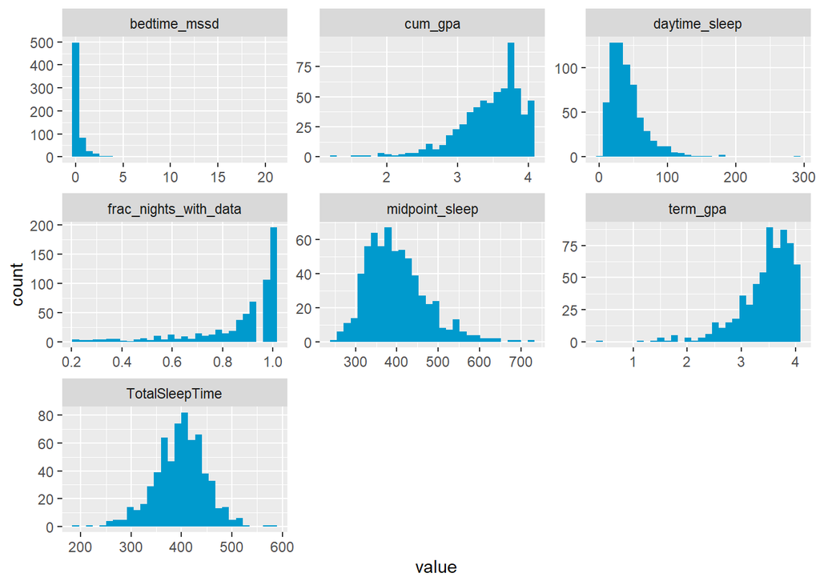

```r
ggplot(data=df.quant,mapping=aes(x=value)) +
  geom_histogram(fill="deepskyblue3",bins=30) +
  facet_wrap(~key,scales='free')
```

```r
disc<- setdiff(names(df), field)
df.disc <- gather(df %>% select(disc))
```

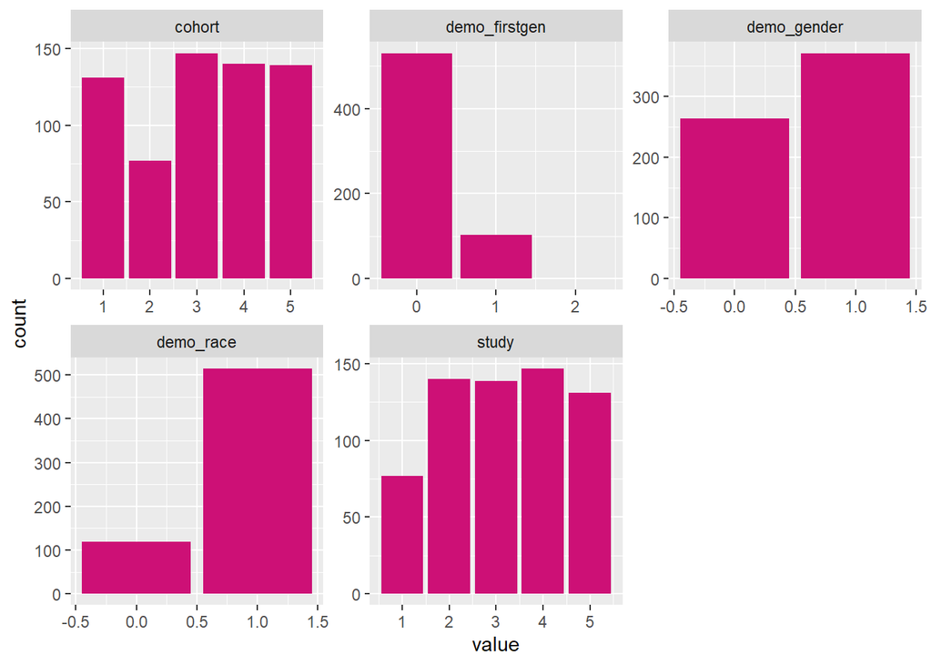

```r
ggplot(data=df.disc,mapping=aes(x=value)) +
  geom_bar(fill="deeppink3") +
  facet_wrap(~key,scales='free')
```

From the second graph it can be seen that there are very few rows that have a value of 2 in demo_firstgen. Therefore it could be proposed that all rows in the table wherein which the demo_firstgen is 2 can be dropped. But it could also be replaced (imputed) with another value so as to actually save that data

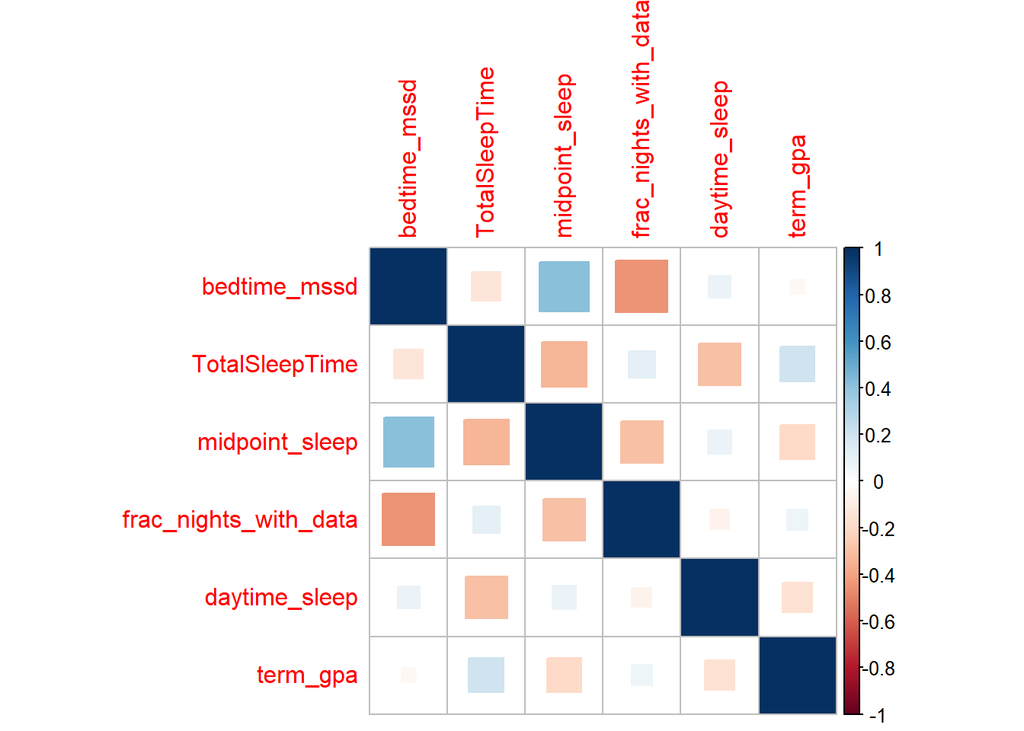

```r
df.quant<-df %>% select(setdiff(field,"cum_gpa"))
df.new<-scale(df.quant)
correl<- cor(df.new)
corrplot(correl, method = "square")
```

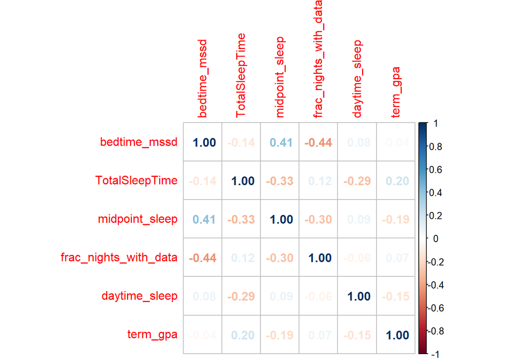

```r
corrplot(correl, method = "number")
```

I have done two visualizations of the correlation matrix. One of them is the correlation matrix which uses the square method to actually use the visual properties of a graph to be able to better understand it. I have done a secondary graph which has numbers this is so that I can get a better understanding of the correlation values of each column with the other columns.

Now let me try it out in a different method wherein which rather than deleting the two columns with values term_units and Zterm_units_Z_of_Z I rather create two dataframes. One with term_units and Zterm_units_Z_of_Z and the other without these two units and redo all of the EDA again to check whether these columns are actually required

```r
df<-read.csv("cmu-sleep.csv")
df.withnona<-df %>% drop_na(term_units)
df.withnona$demo_race[is.na(df.withnona$demo_race)] <- median(df.withnona$demo_race,na.rm = TRUE)
df.withnona$demo_gender[is.na(df.withnona$demo_gender)] <- median(df.withnona$demo_gender,na.rm = TRUE)
df.withnona$demo_firstgen[is.na(df.withnona$demo_firstgen)] <- median(df.withnona$demo_firstgen,na.rm = TRUE)
df.withnona$cohort<-  as.integer(factor(df.withnona$cohort))
sapply(df.withnona, function(x) sum(is.na(x)))
```

```
##            subject_id                 study                cohort
##                     0                     0                     0
##             demo_race           demo_gender         demo_firstgen
##                     0                     0                     0
##          bedtime_mssd        TotalSleepTime        midpoint_sleep
##                     0                     0                     0
## frac_nights_with_data         daytime_sleep               cum_gpa
##                     0                     0                     0
##              term_gpa            term_units      Zterm_units_ZofZ
##                     0                     0                     0
```

```r
head(df.withnona)
```

```
##   subject_id study cohort demo_race demo_gender demo_firstgen bedtime_mssd
## 1        185     5      1         1           1             0    0.1167269
## 2        158     5      1         0           1             0    0.1416808
## 3        209     5      1         1           1             0    1.5292895
## 4        102     5      1         0           1             1    0.1301485
## 5        174     5      1         1           1             0    0.1301809
## 6        184     5      1         1           1             0    0.2094830
##   TotalSleepTime midpoint_sleep frac_nights_with_data daytime_sleep cum_gpa
## 1       432.2000       458.6600             0.8620690      24.16000    3.00
## 2       391.9310       364.4655             1.0000000      13.13793    3.66
## 3       344.3043       560.8913             0.7931034      14.95652    3.57
## 4       392.6207       416.4828             1.0000000      54.55172    3.61
## 5       423.4211       368.7632             0.6551724      10.52632    3.21
## 6       397.4000       353.5800             0.8620690      22.36000    3.20
##   term_gpa term_units Zterm_units_ZofZ
## 1     3.38         73         4.055295
## 2     2.60         64         2.482534
## 3     3.07         63         2.307783
## 4     3.56         61         1.958281
## 5     4.00         61         1.958281
## 6     3.36         60         1.783529
```

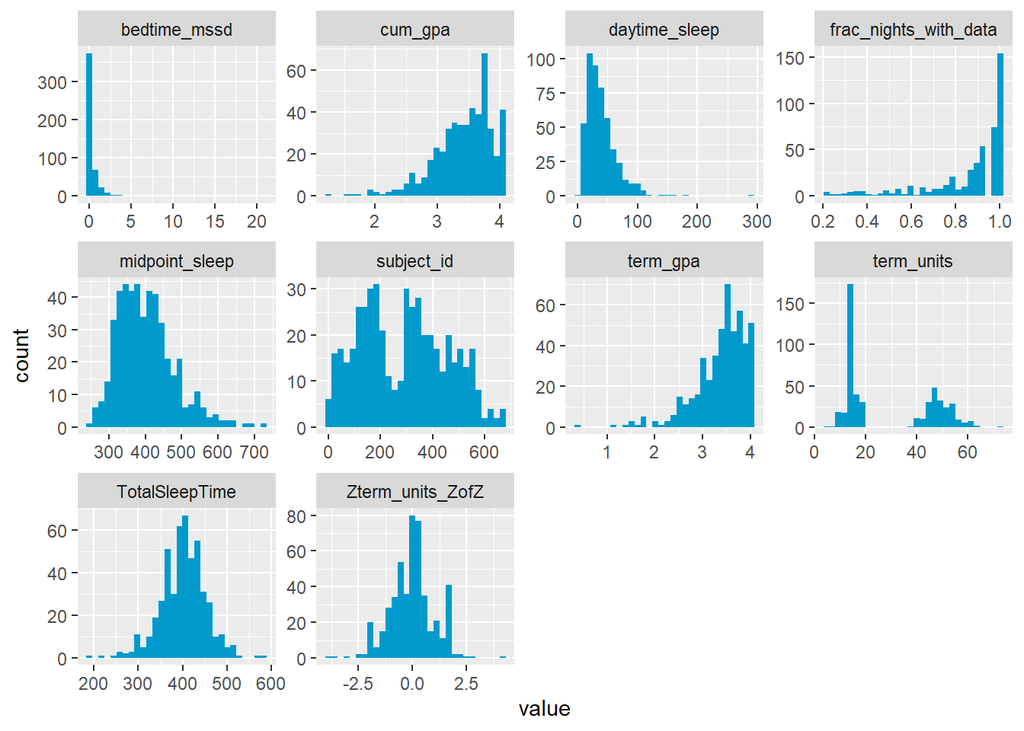

```r
field<-setdiff(names(df.withnona), c("study", "cohort", "demo_race", "demo_gender", "demo_firstgen"))
df.quant <- gather(df.withnona %>% select(field))
ggplot(data=df.quant,mapping=aes(x=value)) +
  geom_histogram(fill="deepskyblue3",bins=30) +
  facet_wrap(~key,scales='free')
```

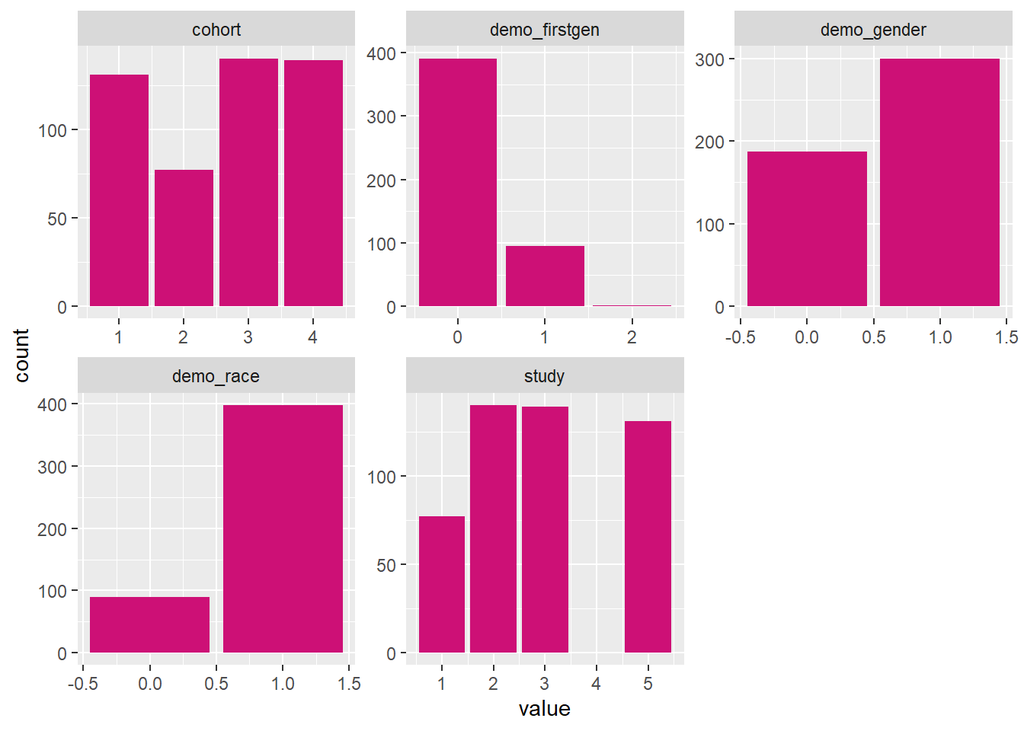

```r
disc<- setdiff(names(df), field)
df.disc <- gather(df.withnona %>% select(disc))
ggplot(data=df.disc,mapping=aes(x=value)) +
  geom_bar(fill="deeppink3") +
  facet_wrap(~key,scales='free')
```

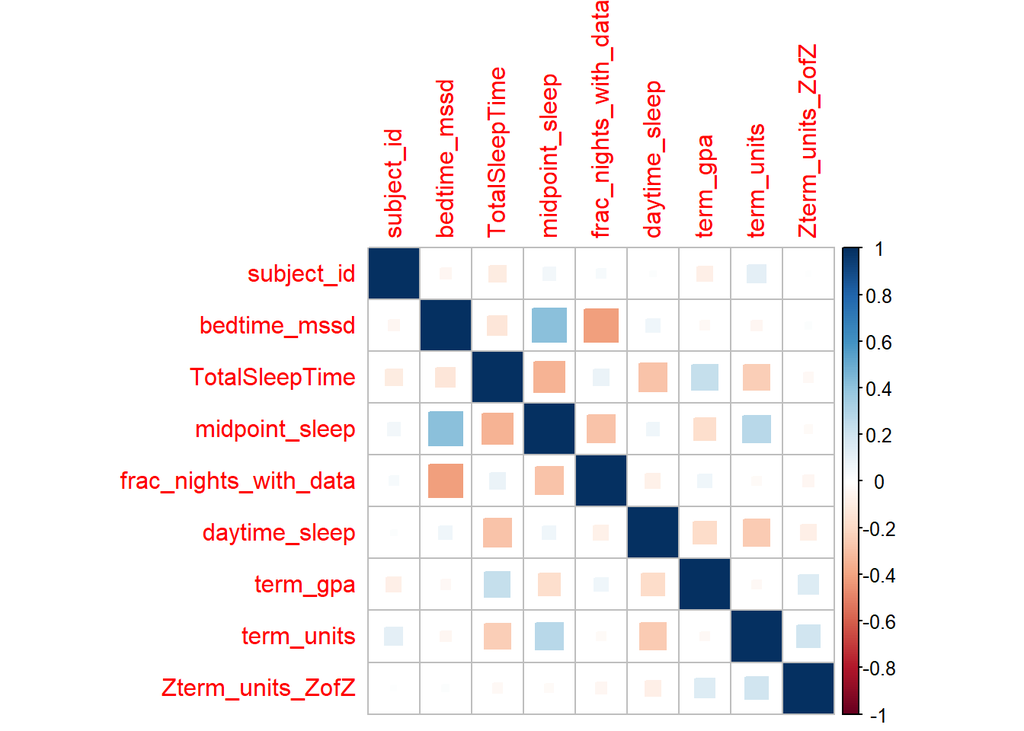

```r
df.quant<-df.withnona %>% select(setdiff(field,"cum_gpa"))
df.new<-scale(df.quant)
correl<- cor(df.new)
corrplot(correl, method = "square")
```

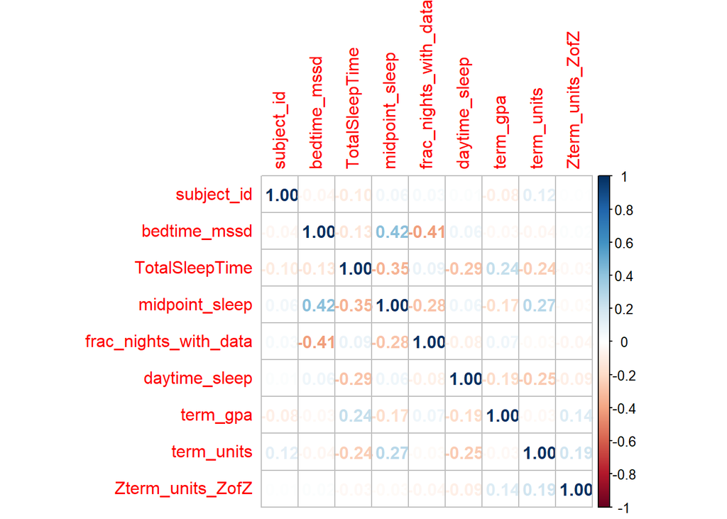

```r
corrplot(correl, method = "number")
```